# N741 Demo of igraph and qgraph packages

Melinda K. Higgins, PhD.

April 16, 2017

## `igraph` package exercise

*These notes were adapted from the course, BIOS560R: “Statistical Methods for Network Science Lab”*

Today we will explore the use of the R package `igraph`, also useful for exploring networks. So, please install the `igraph` package and load it using the `library()` statement.

```r
library(igraph)
```

Do the following to create an edgelist.

```r
datafab <- data.frame(c("Alice","Alice","Bob","Bob",
                        "Sue","Jim","Jim","Jim",
                        "Ellen","Frank"),
                      c("Bob","Sue","Jim","Sue","Ellen",
                        "Frank","Ellen","Karen",
                        "Frank","Karen"))
names(datafab) <- c("person1","person2")
```

You can then turn the data.frame into an `igraph` graph by running the `graph.data.frame()` command:

```r
g <- graph.data.frame(datafab, directed=FALSE)
g
```

```
## IGRAPH UN-- 7 10 --
## + attr: name (v/c)
## + edges (vertex names):
##  [1] Alice--Bob   Alice--Sue   Bob  --Jim   Bob  --Sue   Sue  --Ellen
##  [6] Jim  --Frank Jim  --Ellen Jim  --Karen Ellen--Frank Frank--Karen
```

Or you can find out about the graph with the `summary()` command.

```r
summary(g)
```

```
## IGRAPH UN-- 7 10 --
## + attr: name (v/c)
```

You can list the vertices and edges of the graph with the `V()` and `E()` commands:

```r
V(g)
```

```
## + 7/7 vertices, named:
## [1] Alice Bob   Sue   Jim   Ellen Frank Karen
```

```r
E(g)
```

```
## + 10/10 edges (vertex names):
##  [1] Alice--Bob   Alice--Sue   Bob  --Jim   Bob  --Sue   Sue  --Ellen
##  [6] Jim  --Frank Jim  --Ellen Jim  --Karen Ellen--Frank Frank--Karen
```

There should be 7 vertices and 10 edges.

** Remember to check your work **

Another way to create a graph is to import the necessary information from files in which are saved characteristics such as edge attributes, vertex attributes, and the edges between vertices.

For the next exercise, we will work with the “traits.csv” data file, which has 10 rows (10 people), and 3 columns where:

- column 1 - names of the people
- column 2 - ages of the people
- column 3 - gender of the people

First start with an empty graph:

```r
g<- graph.empty()
```

Next we add vertices, as well as their attributes. This information is stored in the comma separated value format (CSV) file “traits.csv”. There is another .csv file named “relations.csv” which will define the edges. The “relations.csv” file has 34 rows and 5 columns:

- column 1 - person 1
- column 2 - person 2
- column 3 - room
- column 4 - friend
- column 5 - advice

NOTE: Neither file has a header row.

Let’s read both files in:

```r
traits <- read.csv("traits.csv", head=FALSE)
rel<-read.csv("relations.csv", head=FALSE)
```

The head parameter is set to FALSE, instructing R not to interpret the first line of the file as a header. Set this to TRUE if you have a header with column names in your file.

Now, let’s add vertices (from the “traits.csv” data file) to the empty graph as follows:

```r
g <- add.vertices(g, nv=nrow(traits),
                  name = as.character(traits[,1]),
                  age = traits[,2],
                  gender = as.character(traits[,3]))
```

Check that the graph is created properly:

```r
V(g)$name
```

```
##  [1] "Alice Anderson"    "Bob Bradford"      "Cecil Connor"
##  [4] "David Daugher"     "Esmeralda Escobar" "Frank Finley"
##  [7] "Gabi Garbo"        "Helen Hunt"        "Iris Irving"
## [10] "James Jones"
```

```r
V(g)$age
```

```
##  [1] 48 33 45 34 21 36 44 40 25 47
```

```r
V(g)$gender
```

```
##  [1] "F" "M" "F" "M" "F" "M" "F" "F" "F" "M"
```

You can open up the .csv files with Excel, and you will notice that the traits are identified with first and last names, while the relations are identified with the first names only. Let’s strip the last names:

```r
names <- sapply(strsplit(V(g)$name, " "), "[", 1)

# NOTE: the edges as done above will throw and error
# now the ids need to start at 1
# see stackoverflow note at
# http://stackoverflow.com/questions/20730295/error-reading-dataset-in-r
#
# previous code
# ids <- 1:length(names)-1
#
# fix - don't subtract 1 anymore
ids <- 1:length(names)

names(ids) <- names
```

- List the ids.

```r
ids
```

```
##     Alice       Bob     Cecil     David Esmeralda     Frank      Gabi
##         1         2         3         4         5         6         7
##     Helen      Iris     James
##         8         9        10
```

Next create an edge list with vertex ids instead of symbolic names:

```r
from <- as.character(rel[,1])
to <- as.character(rel[,2])
edges <- matrix(c(ids[from], ids[to]), nc=2)
```

- List the edges. How many are there?

```r
edges
```

```
##       [,1] [,2]
##  [1,]    2    1
##  [2,]    3    2
##  [3,]    3    1
##  [4,]    4    1
##  [5,]    4    2
##  [6,]    5    1
##  [7,]    6    1
##  [8,]    6    5
##  [9,]    7    2
## [10,]    7    1
## [11,]    8    1
## [12,]    9    3
## [13,]    9    2
## [14,]    9    5
```

[output cut: 20 more lines]

Finally we can add the edges to the graph, along with the edge attributes (room, friend and advice):

```r
# quick demo from help
#el <- matrix( c("foo", "bar", "bar", "foobar", "foo", "bar2"),
#              nc = 2, byrow = TRUE)
#graph_from_edgelist(el)

graph_from_edgelist(edges)
```

```
## IGRAPH D--- 10 34 --
## + edges:
##  [1]  2-> 1  3-> 2  3-> 1  4-> 1  4-> 2  5-> 1  6-> 1  6-> 5  7-> 2  7-> 1
## [11]  8-> 1  9-> 3  9-> 2  9-> 5 10-> 1 10-> 2 10-> 7  1-> 2  2-> 3  1-> 3
## [21]  1-> 4  2-> 4  1-> 5  1-> 6  5-> 6  2-> 7  1-> 7  1-> 8  3-> 9  2-> 9
## [31]  5-> 9  1->10  2->10  7->10
```

```r
g <- add.edges(g, t(edges),
               room = as.character(rel[,3]),
               friend = rel[,4],
               advice = rel[,5])
```

- List the graph. Summarize it.

```r
g
```

```
## IGRAPH DN-- 10 34 --
## + attr: name (v/c), age (v/n), gender (v/c), room (e/c), friend
## | (e/n), advice (e/n)
## + edges (vertex names):
##  [1] Bob Bradford     ->Alice Anderson
##  [2] Cecil Connor     ->Bob Bradford
##  [3] Cecil Connor     ->Alice Anderson
##  [4] David Daugher    ->Alice Anderson
##  [5] David Daugher    ->Bob Bradford
##  [6] Esmeralda Escobar->Alice Anderson
##  [7] Frank Finley     ->Alice Anderson
## + ... omitted several edges
```

```r
summary(g)
```

```
## IGRAPH DN-- 10 34 --
## + attr: name (v/c), age (v/n), gender (v/c), room (e/c), friend
## | (e/n), advice (e/n)
```

```r
V(g)
```

```
## + 10/10 vertices, named:
##  [1] Alice Anderson    Bob Bradford      Cecil Connor
##  [4] David Daugher     Esmeralda Escobar Frank Finley
##  [7] Gabi Garbo        Helen Hunt        Iris Irving
## [10] James Jones
```

```r
E(g)
```

```
## + 34/34 edges (vertex names):
##  [1] Bob Bradford     ->Alice Anderson
##  [2] Cecil Connor     ->Bob Bradford
##  [3] Cecil Connor     ->Alice Anderson
##  [4] David Daugher    ->Alice Anderson
##  [5] David Daugher    ->Bob Bradford
##  [6] Esmeralda Escobar->Alice Anderson
##  [7] Frank Finley     ->Alice Anderson
##  [8] Frank Finley     ->Esmeralda Escobar
##  [9] Gabi Garbo       ->Bob Bradford
## [10] Gabi Garbo       ->Alice Anderson
## + ... omitted several edges
```

## Importing Graphs

There is no special file format for importing and storing graphs in `igraph` nor in `R`. There are, however, several different methods for importing them. One should be aware that the `igraph` builders recommend using a simple edge list format for larger graphs. In general the most computational efficiency is gained by using edgelists (over adjacency matrices).

### Formats

**Edgelist Format**

The simplest format is the edge list format. In this format, each row of a text file comprises the IDs that denote the two ends of an edge, separated by a blank. It can be read using the `read.graph` function, setting the format to “edgelist” as follows.

- Read in the edges stored in the file `dolphin.txt`, which is a “space-delimited” file with 2 columns of numbers and 159 rows.

```r
# this initally had errors
# I had to recreate the text file
read.graph("dolphin.txt", format="edgelist")
```

```
## IGRAPH D--- 63 159 --
## + edges:
##  [1]  5->10  7->11  8->11  2->12  4->12  7->15  8->15 11->15  2->16  5->16
## [11]  2->17 16->18  3->19  8->19 11->19 15->19 17->20  3->21  9->21 10->22
## [21] 18->22 20->22 20->23 19->24 16->26 17->26 20->26 19->27  3->28 27->28
## [31]  3->29  9->29 19->29 27->29 28->29  3->30 10->30 22->30 12->31 20->31
## [41] 23->31 26->31  9->32 21->32 30->32 19->33 11->34 15->34 14->35 16->35
## [51] 18->35 23->35 16->36 35->36 31->37  3->38 22->38 25->38 10->39 16->39
## [61] 18->39 23->39 35->39 36->39 38->39 16->40 18->40 22->40 35->40 38->41
## [71]  2->42  9->42 16->42 17->42 35->42 38->42 39->42  3->43 11->43 15->43
## [81]  2->44  4->44 12->44 32->44 16->45 31->45 35->45 39->45 40->45  4->46
## + ... omitted several edges
```

```r
# this works
# g2 <- make_ring(10)
# write_graph(g2, "g2.txt", "edgelist")
# rg2 <- read.graph("g2.txt", format="edgelist")
# write_graph(g2, "g4pj.txt", "pajek")
```

Note that the default is that the graph is imported with directed edges. List the edges in the graph. Alternatively you can import the file with undirected edges by adding the option directed = “FALSE” to the read.graph command. Repeat the import of the dolphins data, and list the edges again.

```r
read.graph("dolphin.txt", format="edgelist", directed = FALSE)
```

```
## IGRAPH U--- 63 159 --
## + edges:
##  [1]  5--10  7--11  8--11  2--12  4--12  7--15  8--15 11--15  2--16  5--16
## [11]  2--17 16--18  3--19  8--19 11--19 15--19 17--20  3--21  9--21 10--22
## [21] 18--22 20--22 20--23 19--24 16--26 17--26 20--26 19--27  3--28 27--28
## [31]  3--29  9--29 19--29 27--29 28--29  3--30 10--30 22--30 12--31 20--31
## [41] 23--31 26--31  9--32 21--32 30--32 19--33 11--34 15--34 14--35 16--35
## [51] 18--35 23--35 16--36 35--36 31--37  3--38 22--38 25--38 10--39 16--39
## [61] 18--39 23--39 35--39 36--39 38--39 16--40 18--40 22--40 35--40 38--41
## [71]  2--42  9--42 16--42 17--42 35--42 38--42 39--42  3--43 11--43 15--43
## [81]  2--44  4--44 12--44 32--44 16--45 31--45 35--45 39--45 40--45  4--46
## + ... omitted several edges
```

- Can you tell the difference between how the edges are listed for directed versus undirected graphs?

**Pajek Format**

Pajek is a popular network analysis program for Windows. To read in such a dataset, change the format type to “pajek”" in the `read.graph` command.

- Do this for the karate club dataset, stored as “karate.txt”. Note that it is not necessary to tell read.graph if the relationships are directional of not, that is part of the pajek file.

```r
read.graph("karate.txt", format="pajek")
```

```
## IGRAPH U--- 34 78 --
## + attr: id (v/c)
## + edges:
##  [1]  1-- 2  1-- 3  2-- 3  1-- 4  2-- 4  3-- 4  1-- 5  1-- 6  1-- 7  5-- 7
## [11]  6-- 7  1-- 8  2-- 8  3-- 8  4-- 8  1-- 9  3-- 9  3--10  1--11  5--11
## [21]  6--11  1--12  1--13  4--13  1--14  2--14  3--14  4--14  6--17  7--17
## [31]  1--18  2--18  1--20  2--20  1--22  2--22 24--26 25--26  3--28 24--28
## [41] 25--28  3--29 24--30 27--30  2--31  9--31  1--32 25--32 26--32 29--32
## [51]  3--33  9--33 15--33 16--33 19--33 21--33 23--33 24--33 30--33 31--33
## [61] 32--33  9--34 10--34 14--34 15--34 16--34 19--34 20--34 21--34 23--34
## [71] 24--34 27--34 28--34 29--34 30--34 31--34 32--34 33--34
```

**GML Format**

Another format is GML, standing for (in some circles) graph markup language, and (in other circles) geographic markup language. Again, change the format type to “gml”" in the `read.graph` command.

- Do this for the “football”" dataset

```r
read.graph("football.gml", format="gml")
```

```
## IGRAPH U--- 115 616 --
## + attr: id (v/n), label (v/c), value (v/n)
## + edges:
##  [1]  1-- 2  3-- 4  1-- 5  5-- 6  4-- 6  3-- 7  7-- 8  8-- 9  9--10  1--10
## [11]  5--10  6--11 11--12  6--12  4--12 13--14  3--14  3--15 13--15 15--16
## [21] 14--16  3--16  5--17 10--17  1--17 17--18 13--18 13--19 19--20 18--21
## [31] 21--22  9--22  8--22 10--23  8--23 22--23  9--23 23--24 10--24  5--24
## [41] 17--24  1--24 12--25 25--26  2--26  4--27 13--27 15--27 27--28 18--28
## [51]  2--28 18--28  5--29 12--29 25--29 20--30 30--31 20--31 19--32 32--33
## [61] 22--33 16--33 14--33  7--33  1--34  2--34 26--34 20--34 32--35 27--35
## [71] 13--35 19--35 35--36  1--36 30--36 20--36 31--36 19--37 13--37 21--37
## + ... omitted several edges
```

## Plotting graphs in `igraph`

There are two ways to plot graphs.

`plot.igraph(name of igraph object here)`

will give you a static plot, while

`tkplot(name of igraph object here)`

will give you more interactive capability, although I have not tested that. Try these for the graph g that you created from reading in the .csv files above.

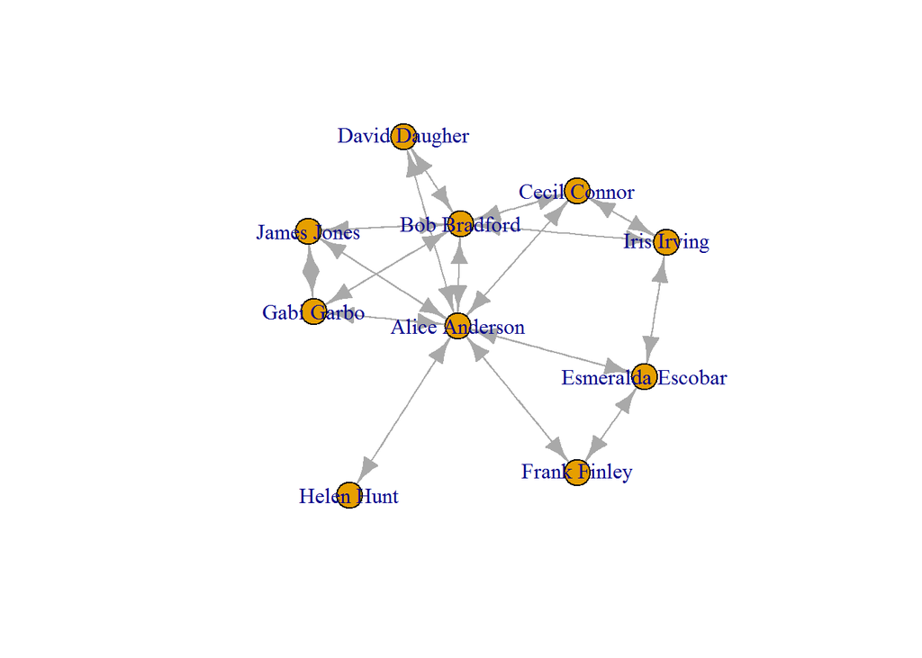

```r
plot.igraph(g)
```

```r
tkplot(g)
```

```
## [1] 1
```

**NOTE:** You’ll need to run the `tkplot()` from the command line to see the interactivity - this does NOT show in the final HTML file from the RMD.

- What are the differences between the two plots?

*(NB, I had good luck when I issued the tkplot command as follows, changing the edge colors)*

**RUN these lines of code interactively**

```r
E(g)$color <- "black"
E(g)[ room=="Y" ]$color <- "red"
tkplot(g, layout=layout.kamada.kawai,
       edge.color=E(g)$color)
```

```
## [1] 2
```

## Graph and Vertex Properties

You can determine the degree sequence of a graph as follows:

`degree(graph name here)`

Likewise the diameter of a graph:

`diameter(graph name here)`

```r
degree(g)
```

```
##    Alice Anderson      Bob Bradford      Cecil Connor     David Daugher
##                16                12                 6                 4
## Esmeralda Escobar      Frank Finley        Gabi Garbo        Helen Hunt
##                 6                 4                 6                 2
##       Iris Irving       James Jones
##                 6                 6
```

```r
diameter(g)
```

```
## [1] 3
```

One can calculate closeness centrality with the closeness command as follows:

`closeness(graph name here)`

or estimate it with

`closeness.estimate(graph name here)`

This statement needs a `cutoff` estimate which is useful for large graphs. You can also set this to 0 or a negative number to get the exact closeness scores.

```r
closeness(g)
```

```
##    Alice Anderson      Bob Bradford      Cecil Connor     David Daugher
##        0.10000000        0.08333333        0.06666667        0.06250000
## Esmeralda Escobar      Frank Finley        Gabi Garbo        Helen Hunt
##        0.06666667        0.06250000        0.06666667        0.05555556
##       Iris Irving       James Jones
##        0.06250000        0.06666667
```

```r
# need an estimate for cutoff
# let's set this to 0.06
closeness.estimate(g, cutoff = 0.06)
```

```
##    Alice Anderson      Bob Bradford      Cecil Connor     David Daugher
##        0.05555556        0.02777778        0.01587302        0.01388889
## Esmeralda Escobar      Frank Finley        Gabi Garbo        Helen Hunt
##        0.01587302        0.01388889        0.01587302        0.01234568
##       Iris Irving       James Jones
##        0.01587302        0.01587302
```

```r
# set to 0 to get exact closeness scores
closeness.estimate(g, cutoff = 0)
```

```
##    Alice Anderson      Bob Bradford      Cecil Connor     David Daugher
##        0.10000000        0.08333333        0.06666667        0.06250000
## Esmeralda Escobar      Frank Finley        Gabi Garbo        Helen Hunt
##        0.06666667        0.06250000        0.06666667        0.05555556
##       Iris Irving       James Jones
##        0.06250000        0.06666667
```

For directed graphs, you can use the mode option here to determine the in-, out-, or all closeness, as follows:

```r
closeness(g, mode="in")
```

```
##    Alice Anderson      Bob Bradford      Cecil Connor     David Daugher
##        0.10000000        0.08333333        0.06666667        0.06250000
## Esmeralda Escobar      Frank Finley        Gabi Garbo        Helen Hunt
##        0.06666667        0.06250000        0.06666667        0.05555556
##       Iris Irving       James Jones
##        0.06250000        0.06666667
```

```r
closeness(g, mode="out")
```

```
##    Alice Anderson      Bob Bradford      Cecil Connor     David Daugher
##        0.10000000        0.08333333        0.06666667        0.06250000
## Esmeralda Escobar      Frank Finley        Gabi Garbo        Helen Hunt
##        0.06666667        0.06250000        0.06666667        0.05555556
##       Iris Irving       James Jones
##        0.06250000        0.06666667
```

```r
closeness(g, mode="all")
```

```
##    Alice Anderson      Bob Bradford      Cecil Connor     David Daugher
##        0.10000000        0.08333333        0.06666667        0.06250000
## Esmeralda Escobar      Frank Finley        Gabi Garbo        Helen Hunt
##        0.06666667        0.06250000        0.06666667        0.05555556
##       Iris Irving       James Jones
##        0.06250000        0.06666667
```

```r
# can't get this to run
# closeness(graph=g,
#           mode=c("in", "out", "all"))
```

Similarly one can calculate betweenness centrality with the betweenness command as follows:

`betweenness(graph name here)`

or estimate it with

`betweenness.estimate(graph name here)`

```r
betweenness(g)
```

```
##    Alice Anderson      Bob Bradford      Cecil Connor     David Daugher
##         39.000000         12.333333          1.333333          0.000000
## Esmeralda Escobar      Frank Finley        Gabi Garbo        Helen Hunt
##          3.333333          0.000000          0.000000          0.000000
##       Iris Irving       James Jones
##          2.000000          0.000000
```

```r
# try with cutoff of 10
betweenness.estimate(g, cutoff=10)
```

```
##    Alice Anderson      Bob Bradford      Cecil Connor     David Daugher
##         39.000000         12.333333          1.333333          0.000000
## Esmeralda Escobar      Frank Finley        Gabi Garbo        Helen Hunt
##          3.333333          0.000000          0.000000          0.000000
##       Iris Irving       James Jones
##          2.000000          0.000000
```

```r
# try with cutoff of 0
betweenness.estimate(g, cutoff=0)
```

```
##    Alice Anderson      Bob Bradford      Cecil Connor     David Daugher
##                 0                 0                 0                 0
## Esmeralda Escobar      Frank Finley        Gabi Garbo        Helen Hunt
##                 0                 0                 0                 0
##       Iris Irving       James Jones
##                 0                 0
```

Another important option for this command is “directed=TRUE” to use when consideration of direction in digraphs is important.

- Calculate the degree sequence, average degree, diameter, betweenness centrality and closeness centrality of the social relationship graph that we created as well as for the dolphins and football networks.

```r
# do this exercise IN CLASS
```

- LAB 1

In the folder there is the dataset `adjnoun.gml`, which describes the word concurrencies in David Copperfield. For this graph, provide a 1-2 page description of it. For each one, give its basic characteristics in tabular format: number of vertices, number of edges, list any attributes of vertices and attributes if known (NB, direction is an attribute), give the graph and vertex properties listed above (including average degree). Include a plot.